# presentation-live

## Druh × ostrov: každý tučňák jedním čtverečkem

Kategoriální × kategoriální: čteme počty nebo podíly v kombinacích kategorií

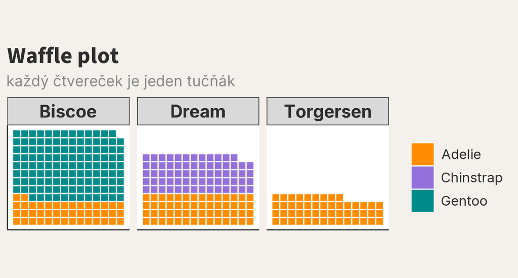

**Waffle plot** ukáže počty jako jednotky: vidíme složení i velikost skupin najednou.

## Druh × ostrov: sloupce počtů a podílů

[figure not shown]

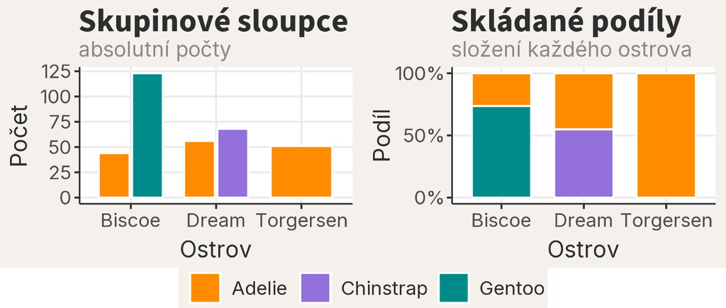

**Skupinové sloupce** porovnají absolutní počty mezi ostrovy.

**Skládané podíly** ukážou složení ostrova, ale skryjí, kolik tučňáků tam bylo.

## Druh × ostrov: hezčí, nebo čitelnější?

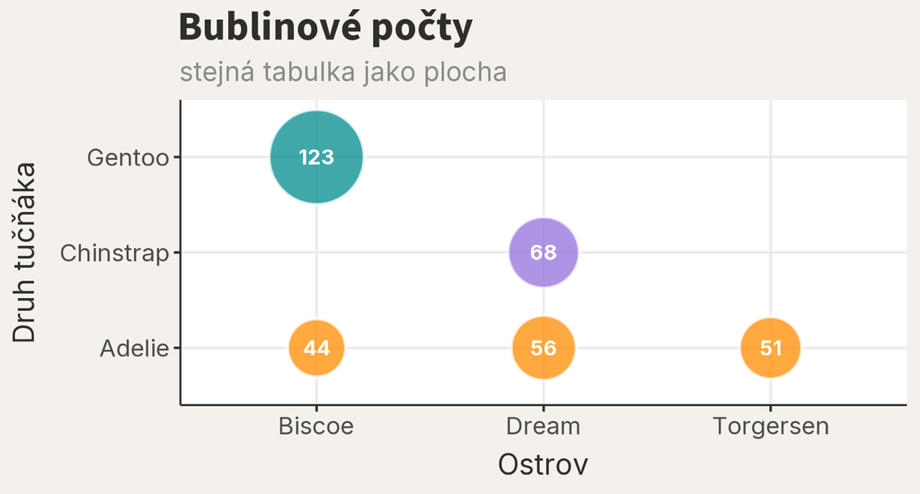

Bubliny jsou efektní, ale porovnávání ploch je pro oko těžší než porovnávání délek sloupců.

## Kdy potřebujeme počty a kdy podíly?

Počty

Kdy potřebujeme vědět, kolik pozorování opravdu máme?

Podíly

Kdy nás zajímá složení skupiny bez ohledu na její velikost?

## Který graf zvolit jako první?

| Typy proměnných | Dobrý první graf | Co v něm čteme |
| --- | --- | --- |
| numerická × numerická | bodový graf | směr, tvar, rozptýlení, odlehlá pozorování |
| kategoriální × numerická | body ve skupinách; boxplot + body | rozdíly mezi skupinami, překryv, rozptýlení uvnitř skupin |
| kategoriální × kategoriální | tabulka četností; sloupce počtů nebo podílů | složení kombinací, počty vs. podíly |

Typy proměnných zúží možnosti. Biologická otázka rozhodne, co má graf zvýraznit.

Co nesmíme skrýt?

Boxplot skryje tvar dat, podíly skryjí počty.

# Závěr

## Co přidá model?

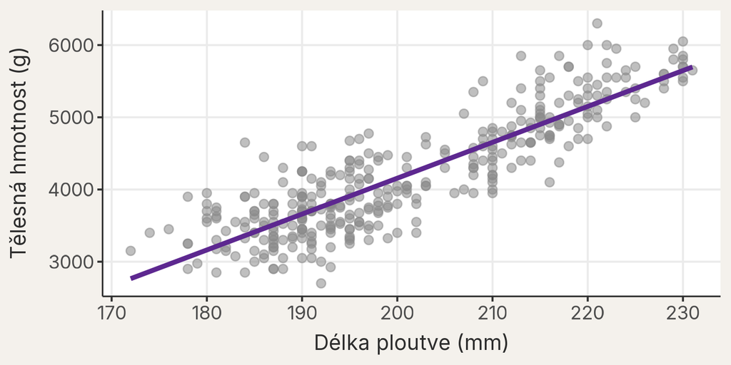

Přímka popíše vztah v původních jednotkách: o kolik gramů se typicky mění hmotnost na každý 1 mm délky ploutve? To bude téma následující lekce.

## Shrnutí

- Pro dvě numerické proměnné je první volbou bodový graf.
- Z grafu čteme současně směr vztahu i rozptýlení bodů.
- Korelace vztah shrne číslem, ale nenahradí samotný graf.
- Typ dvojice proměnných zúží výběr grafu; otázka rozhodne, co má graf ukázat.
- Viditelný vzor ještě není důkaz příčiny.

## Co potřebujete vidět, než napíšete „delší ploutev, těžší tučňák“?

Jaké tři otázky položíte autorovi, který vám ukáže jen *r* = 0,87 bez grafu?

Řekněte sousedovi jednou větou

Kterou z otázek byste položili jako první, a proč?